# Introduction to R Programming

15/05/2019

## R basics

## Materials

You can find the materials for today's course on my website. Either go to the Moodle page for MY591 and click on the links, or:

- Assignment: tom.paskhal.is/MY591/exercises.html
- Slides: tom.paskhal.is/MY591/intro_to_r.html
- Source Code: github.com/tpaskhalis/MY591_Introduction_to_R

It is worth noting that both the assignment and the slides were all created using R and RStudio.

## I have used STATA/SPSS for years, why learn R?

Because:

- R is free
- R is open source and has excellent package ecosystem
- R is very versatile
- R is *very* good for data visualisation
- R can accomodate more than one data frame in memory at the same time

On the other hand:

- R has a steep(er) learning curve

## Popularity of data analysis software

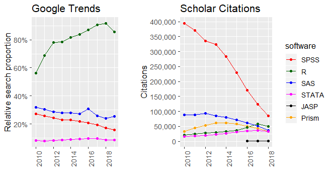

More discussion on this can be found [here](http://lindeloev.net/spss-is-dying/).

## R and RStudio

- As in STATA, you can either use a script (do file) to save commands and then run them, or write commands directly into the console
- It is perfectly possible to use the base R environment for everything, but most people do not do this
- Today we will mostly be using RStudio, which is a graphical user interface (GUI) for R
- RStudio has a host of useful features which make it an excellent environment for learning R
  - Intuitive interface
  - Syntax highlighting
  - Easy data overview
  - Project management

## RStudio demonstration

## Basic mathematical operations in R

```r
1 + 1
```

```
## [1] 2
```

```r
5 - 3
```

```
## [1] 2
```

```r
6 / 2
```

```
## [1] 3
```

```r
4 * 4
```

```
## [1] 16
```

## Basic mathematical operations in R

- Other typical mathematical functions are also hard-coded:

```r
sum(<numbers>) # Sum
mean(<numbers>) # Mean
median(<numbers>) # Median
sd(<numbers>) # Standard Deviation
log(<number>) # Logarithm
exp(<number>) # Exponent
sqrt(<number>) # Square root
```

## Basic operations in R

R also understands logical operators:

- `<` : less than
- `>` : greater than
- `==` : equal to (note, not `=`)
- `>=` : greater than or equal to
- `<=` : less than or equal to
- `!=` : not equal to
- `&` : and
- `|` : or

## R `objects`

- The entities that R creates and manipulates are known as objects
- These may be vectors, matrices, character strings, functions
- Objects are created using the *assignment operator*: `<-`
- Once created, an object is stored in your current *global environment*

```r
x1 <- 10
print(x1)
```

```
## [1] 10
```

```r
x2 <- 4
x3 <- x1 - x2
print(x3)
```

```
## [1] 6
```

## Data Structures

## `vector` - the basic building block of R.

A vector is a collection of elements which all share the same type.

We use the `c()` function to concatenate observations into a single vector.

- Numeric

```r
num_vec <- c(150, 178, 67.7, 905, 12)
print(num_vec)
```

```
## [1] 150.0 178.0  67.7 905.0  12.0
```

```r
num_vec
```

```
## [1] 150.0 178.0  67.7 905.0  12.0
```

## `vector` - the basic building block of R.

There are no scalars (atomic units) in R

A scalar is just a vector of length 1

- Character

```r
char_vec <- c("apple", "pear", "plum", "pineapple", "strawberry")
length(char_vec)
```

```
## [1] 5
```

```r
char_scalar <- "banana"
length(char_scalar)
```

```
## [1] 1
```

## `vector` - the basic building block of R.

When creating new objects, keep in mind reserved words and try to avoid using them in names

- Logical (Boolean)

```r
log_vec <- c(FALSE, FALSE, FALSE, TRUE, TRUE)
log_vec
```

```
## [1] FALSE FALSE FALSE  TRUE  TRUE
```

```r
log_vec2 <- c(F, F, F, T, T)
log_vec2
```

```
## [1] FALSE FALSE FALSE  TRUE  TRUE
```

## `vector` - the basic building block of R.

- Factor

A factor is similar to a character vector, but here each unique element is associated with a numerical value which represents a category:

```r
fac_vec <- as.factor(c("a", "b", "c", "b", "b", "c"))
fac_vec
```

```
## [1] a b c b b c
## Levels: a b c
```

```r
as.numeric(fac_vec)
```

```
## [1] 1 2 3 2 2 3
```

## `vector` - the basic building block of R.

- Date

A date is similar to a numeric vector, as it stores the number of days, but it can assume a variety of forms:

```r
date_vec <- as.Date(c("2001/07/06", "2005/05/05", "2010/06/05", "2015/07/05", "2017/08/06"))
date_vec
```

```
## [1] "2001-07-06" "2005-05-05" "2010-06-05" "2015-07-05" "2017-08-06"
```

```r
as.numeric(date_vec)
```

```
## [1] 11509 12908 14765 16621 17384
```

```r
format(date_vec, "%d/%m/%Y")
```

```
## [1] "06/07/2001" "05/05/2005" "05/06/2010" "05/07/2015" "06/08/2017"
```

## `vector` subsetting

To subset a `vector`, use square parenthesis to index the elements you would like via `object[index]`:

- Numerical subsetting

```r
char_vec
```

```
## [1] "apple"      "pear"       "plum"       "pineapple"  "strawberry"
```

```r
char_vec[1:3]
```

```
## [1] "apple" "pear"  "plum"
```

## `vector` subsetting

Instead of passing indices, it is also possible to use a logical vector to specify the required elements:

- Logical subsetting

```r
log_vec
```

```
## [1] FALSE FALSE FALSE  TRUE  TRUE
```

```r
char_vec[log_vec]
```

```
## [1] "pineapple"  "strawberry"
```

## `vector` operations

In R, mathematical operations on vectors occur elementwise:

```r
fib <- c(1, 1, 2, 3, 5, 8, 13, 21)
fib[1:7]
```

```
## [1]  1  1  2  3  5  8 13
```

```r
fib[2:8]
```

```
## [1]  1  2  3  5  8 13 21
```

```r
fib[1:7] + fib[2:8]
```

```
## [1]  2  3  5  8 13 21 34
```

## `vector` operations

It is also possible to perform logical operations on vectors:

```r
fib <- c(1, 1, 2, 3, 5, 8, 13, 21)
fib_gt_5 <- fib > 5
fib_gt_5
```

```
## [1] FALSE FALSE FALSE FALSE FALSE  TRUE  TRUE  TRUE
```

We can also combine logical operators

```r
fib_gt_5_or_ls_2 <- fib > 5 | fib < 2
fib_gt_5_or_ls_2
```

```
## [1]  TRUE  TRUE FALSE FALSE FALSE  TRUE  TRUE  TRUE
```

## `matrix`

A matrix is just a collection of vectors! I.e. it is a 2-dimensional vector that has 2 additional attributes: the number of rows and columns

As for vectors all elements of a matrix must be of the same type

```r
mat <- matrix(data = 1:25, nrow = 5, ncol = 5)
mat
```

```
##      [,1] [,2] [,3] [,4] [,5]
## [1,]    1    6   11   16   21
## [2,]    2    7   12   17   22
## [3,]    3    8   13   18   23
## [4,]    4    9   14   19   24
## [5,]    5   10   15   20   25
```

## `list`

A `list` is a collection of R objects of different types

```r
l <- list(element1 = num_vec,
          element2 = mat[1:2,1:2],
          element3 = "Farmers' Market")
l
```

```
## $element1
## [1] 150.0 178.0  67.7 905.0  12.0
##
## $element2
##      [,1] [,2]
## [1,]    1    6
## [2,]    2    7
##
## $element3
## [1] "Farmers' Market"
```

## `list` subsetting

Individual elements of a `list` object can be subset using `$` or `[[` operators:

```r
l$element2
```

```
##      [,1] [,2]
## [1,]    1    6
## [2,]    2    7
```

```r
l[[2]]
```

```
##      [,1] [,2]
## [1,]    1    6
## [2,]    2    7
```

## `data.frame` - the workhorse of data analysis.

A `data.frame` is an R object in which the columns can be of different types

Despite their matrix-like appearance, data frames in R are lists, where all elements are of equal length!

```r
df <- data.frame(weight = num_vec, fruit = char_vec, berry = log_vec)
df
```

```
##   weight      fruit berry
## 1  150.0      apple FALSE
## 2  178.0       pear FALSE
## 3   67.7       plum FALSE
## 4  905.0  pineapple  TRUE
## 5   12.0 strawberry  TRUE
```

## `matrix` and `data.frame` subsetting

To subset a `matrix` or `data.frame`, you need to specify both rows and columns:

```r
mat[1:3, 1:3]
```

```
##      [,1] [,2] [,3]
## [1,]    1    6   11
## [2,]    2    7   12
## [3,]    3    8   13
```

```r
df[1, ]
```

```
##   weight fruit berry
## 1    150 apple FALSE
```

## `matrix` and `data.frame` subsetting

We can also subset to remove rows or columns by using the `-` operator applied to the `c` function:

```r
mat[-c(1:3), -c(1:3)]
```

```
##      [,1] [,2]
## [1,]   19   24
## [2,]   20   25
```

In the code, `1:3` creates a vector of the integers 1, 2 and 3, and the `-` operator negates these. We wrap the vector in the `c` function so that `-` applies to each element, and not just the first element.

## `functions` - the backbone of R operations.

All operations on objects in R are done with functions.

```r
fun(arg1, arg2, ...)
```

Where

- `fun` is the name of the function
- `arg1` is the first argument passed to the function
- `arg2` is the second argument passed to the function

## `function` example

Let's consider the `mean()` function. This function takes two main arguments:

```r
mean(x, na.rm = FALSE)
```

Where `x` is a numeric vector, and `na.rm` is a logical value that indicates whether we'd like to remove missing values (`NA`).

```r
vec <- c(1, 2, 3, 4, 5)
mean(x = vec, na.rm = FALSE)
```

```
## [1] 3
```

```r
vec <- c(1, 2, 3, NA, 5)
mean(x = vec, na.rm = TRUE)
```

```
## [1] 2.75
```

## `function` example

We can also perform calculations on the output of a function:

```r
mean(num_vec) * 3
```

```
## [1] 787.62
```

Which means that we can also have nested functions:

```r
log(mean(num_vec))
```

```
## [1] 5.570403
```

We can also assign the output of any function to a new object for use later:

```r
log_fruit <- log(mean(num_vec)) # The logarithm of average fruit weight
```

## Basic operations are `functions` in disguise!

All the basic operations on R `objects` that we have encountered so far are, in fact, `functions`:

```r
`+`(1,1)
```

```
## [1] 2
```

```r
`-`(5,3)
```

```
## [1] 2
```

```r
`[`(char_vec, 1:3)
```

```
## [1] "apple" "pear"  "plum"
```

## User defined `functions`

Functions are also objects, and we can create our own. We define a function as follows:

```r
sum2 <- function(a, b){
  return(a + b)
}

res <- sum2(a = 5, b = 50)
res
```

```
## [1] 55
```

Note that the function itself, and the result returned by the function are both objects!

## Help!

R has an inbuilt help facility which provides more information about any function:

```r
?summary
help(summary)
```

The quality of the help varies *hugely* across packages.

[Stackoverflow](https://stackoverflow.com/) is a good resource for many standard tasks.

For custom packages it is often helpful to check the **issues** page on the [GitHub](https://github.com/).

E.g. for `ggplot2`: https://github.com/tidyverse/ggplot2/issues

Or, indeed, any search engine [#LMDDGTFY](https://lmddgtfy.net/).

## Exercise One

## Data manipulation and exploration

## Reading data into R (.csv)

```r
sim.df <- read.csv(file = "file.csv")
```

- `df` is an R data.frame object (you could call this anything)
- `file.csv` is a .csv file with your data
- `<-` is the assignment operator
- In order for R to access `file.csv`, it will have to be saved in your current working directory
- Before recently, the standard advice was to use `getwd()` and `setwd()`.
- **Try to avoid it!** Instead, create new RStudio project and use relative paths:

```r
sim.df <- read.csv(file = "./data/file.csv")
```

- More details can be found [here](https://www.tidyverse.org/articles/2017/12/workflow-vs-script/)

## Reading data into R (STATA .dta, SPSS .sav)

```r
install.packages("haven") # Install the "haven" package
library("haven") ## Loads an additional package that deals with STATA files
sim.df <- haven::read_dta(file = "./data/file.dta")
sim.df <- haven::read_sav(file = "./data/file.sav")
```

- The `haven` package is not automatically installed in R so we need to do that ourselves
- `df` is still a R data.frame objects
- `file.dta` is a .dta (used by STATA) file with your data
- `file.sav` is a .sav (used by SPSS) file with your data
- `<-` is the usual assignment operator

## Descriptive statistics `functions`

R includes a number of helpful functions for exploring your data:

```r
View(sim.df) # View data in spreadsheet-style
names(sim.df) # Names of the variables in your data
head(sim.df) # First n (six, by default) rows of the data
tail(sim.df) # Last n (six, by default) rows of the data
str(sim.df) # "Structure" of any R object
summary(sim.df) # Summary statistics for each of the columns in the data
dim(sim.df) # Dimensions of data
mean(sim.df$var) # Mean of a numeric vector
sd(sim.df$var) # Standard deviation of a numeric vector
range(sim.df$var) # Range of a numeric vector
quantile(sim.df$var) # Quantiles of a numeric vector
```

## `head`

By varying argument `n`, we can adjust the number of top rows we want to inspect:

```r
head(sim.df, n = 5)
```

```
##            x         y          z g
## 1  1.8068729 1.1338624 0.08688987 d
## 2 -1.2486526 0.5960640 0.27517432 e
## 3 -0.1355884 0.8004329 0.70459357 a
## 4  0.9505454 2.2648623 0.61059223 a
## 5 -1.2711097 0.8887924 0.88313813 c
```

Can also be used in combination with `View()`:

```r
View(head(sim.df, n = 50))
```

## `str`

`str()` applied to data frames is particularly useful in inferring types of variables in the data

```r
str(sim.df)
```

```
## 'data.frame':    1000 obs. of  4 variables:
##  $ x: num  1.807 -1.249 -0.136 0.951 -1.271 ...
##  $ y: num  1.134 0.596 0.8 2.265 0.889 ...
##  $ z: num  0.0869 0.2752 0.7046 0.6106 0.8831 ...
##  $ g: Factor w/ 6 levels "a","b","c","d",..: 4 5 1 1 3 6 1 3 6 5 ...
```

## `summary`

```r
summary(sim.df)
```

```
##        x                    y                 z             g
##  Min.   :-2.7467901   Min.   :-3.2166   Min.   :0.0007827   a:177
##  1st Qu.:-0.6505946   1st Qu.:-0.2343   1st Qu.:0.2568557   b:161
##  Median : 0.0003546   Median : 0.4703   Median :0.4932571   c:173
##  Mean   : 0.0161324   Mean   : 0.4774   Mean   :0.4954730   d:141
##  3rd Qu.: 0.6626705   3rd Qu.: 1.1694   3rd Qu.:0.7341048   e:177
##  Max.   : 3.0778088   Max.   : 3.5594   Max.   :0.9994499   f:171
```

## `pairs`

`pairs()` produces a matrix of bivariate scatterplots

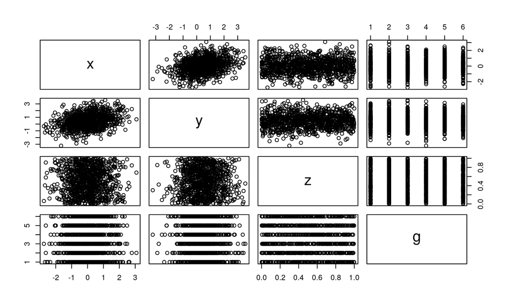

```r
pairs(sim.df)
```

## `range`

Suppose you would like to find the range of a variable in your `data.frame`. The following will not work:

```r
range(sim.df)
```

```
## Error in FUN(X[[i]], ...): only defined on a data frame with all numeric variables
```

Right, we cannot take the range of the entire data! Some of the variables are not numeric, and therefore do not have a range…

## `range`

- We can subset using square parenthesis, or
- We can use the `[[` operator and access the variable of interest by position, or
- We can use the `$` operator and access the variable of interest by name

Note that the last two treat `data.frame` as a list with variables as elements

```r
range(sim.df[,1])
range(sim.df[[1]])
```

```r
range(sim.df$x)
```

```
## [1] -2.746790  3.077809
```

## Plots and graphs

## Introduction

- Plots are one of the great strenghts of R
- There are two main frameworks for plotting
- Base R graphics
- `ggplot`
- Which should you use? It is a matter of preference!

## Base R plots

The basic plotting syntax is very simple. `plot(x_var, y_var)` will give you a scatter plot:

```r
plot(sim.df$x, sim.df$y)
```

## Base R plots

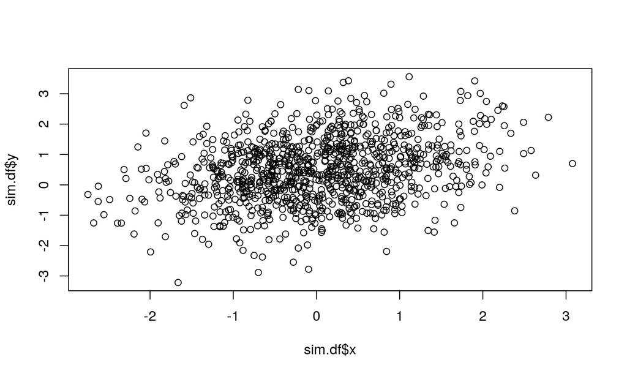

Hmm, let's work on that.

## Base R plots

The plot function takes a number of arguments (`?plot` for a full list). The fewer you specify, the uglier your plot:

```r
plot(x = sim.df$x, y = sim.df$y,
     xlab = "X variable",
     ylab = "Y variable",
     main = "Awesome plot title",
     pch = 19, # Solid points
     cex = 0.5, # Smaller points
     bty = "n", # Remove surrounding box
     col = sim.df$g # Colour by grouping variable
     )
```

## Base R plots

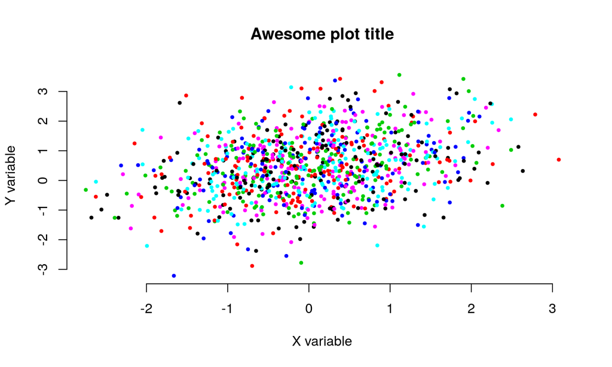

## Base R plots

The default behaviour of `plot()` depends on the type of input variables for the `x` and `y` arguments. If `x` is a factor variable, and `y` is numeric, then R will produce a boxplot:

```r
plot(x = sim.df$g, y = sim.df$x)
```

## Base R plots

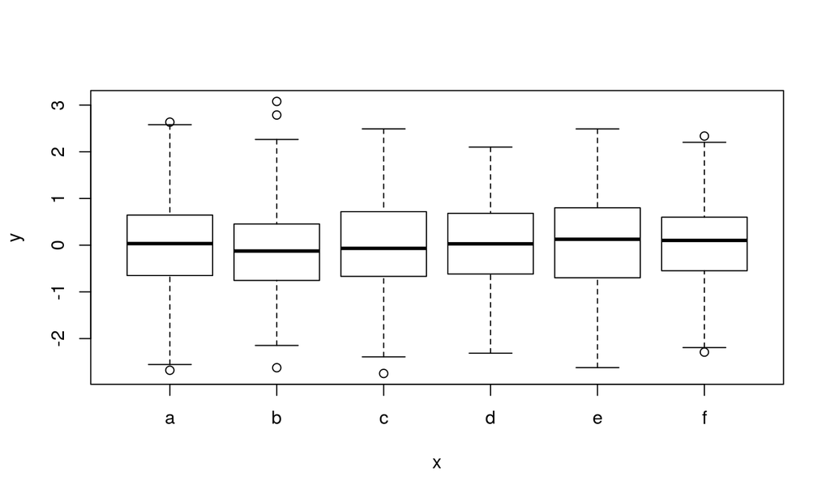

## `ggplot`

A very popular alternative to base R plots is the `ggplot2` library (the *2* in the name refers to the second iteration, which is the standard). This is a separate package (i.e. it is not a part of the base R environment) but is very widely used.

- Based on the Grammar of Graphics data visualisation scheme:

Wilkinson, L. (2005). *The Grammar of Graphics* 2nd Ed. Heidelberg: Springer. https://doi.org/10.1007/0-387-28695-0

Wickham, H. (2010). A Layered Grammar of Graphics. *Journal of Computational and Graphical Statistics*, 19(1), 3–28. https://doi.org/10.1198/jcgs.2009.07098

- Graphs are broken into multiple layers
- Layers can be recycled across multiple plots

## `ggplot`

Let's recreate the previous scatter plot using `ggplot`:

```r
library("ggplot2")
ggplot(data = sim.df, aes(x = x, y = y, col = g)) +
  # Add scatterplot
  geom_point() +
  # Change axes labels and plot title
  labs(x = "X variable",
       y = "Y variable",
       title = "Awesome plot title") +
  # Change default grey theme to black and white
  theme_bw()
```

## `ggplot`

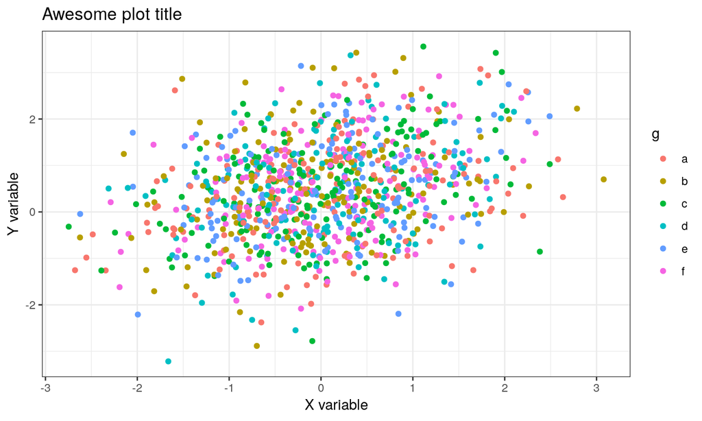

## `ggplot`

One nice feature of `ggplot` is that it is very easy to create facet plots:

```r
library("ggplot2")
ggplot(data = sim.df, aes(x = x, y = y, col = g)) +
  geom_point() +
  labs(x = "X variable",
       y = "Y variable",
       title = "Awesome plot title") +
  theme_bw() +
  # Separate plots by variable g
  facet_wrap(~ g)
```

## `ggplot`

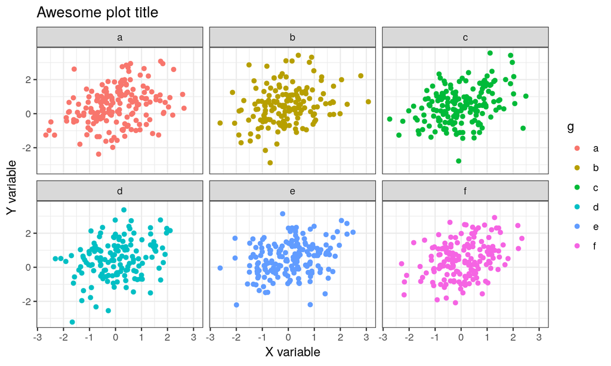

## Other examples of pretty R graphics

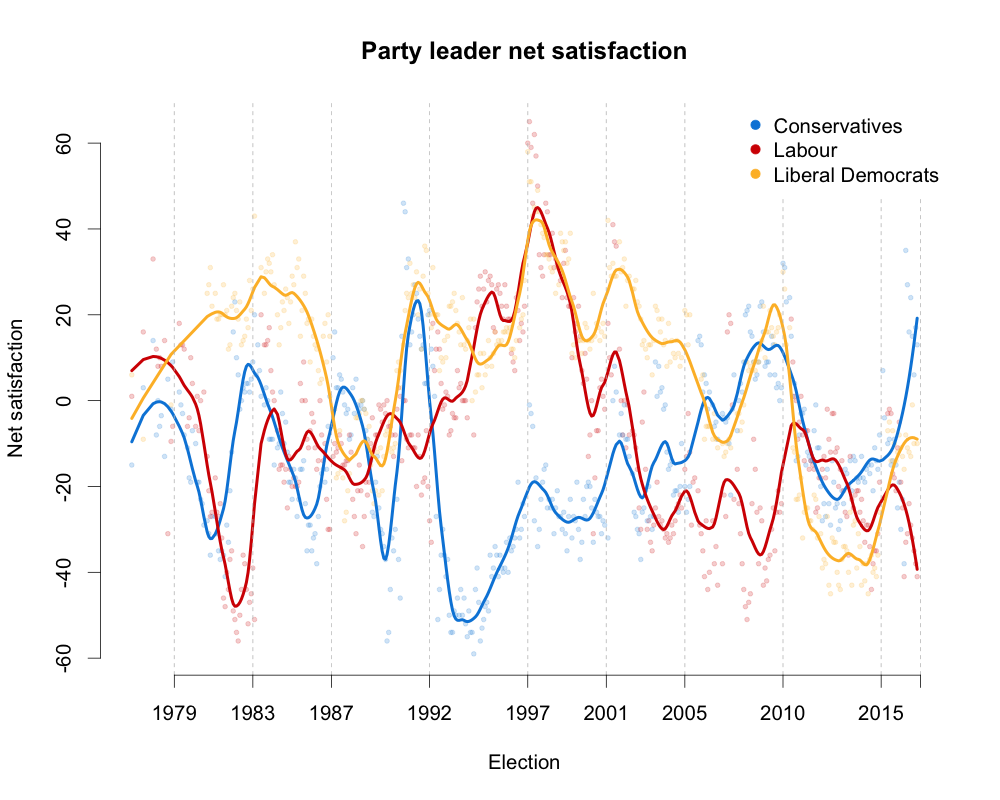

## Other examples of pretty R graphics

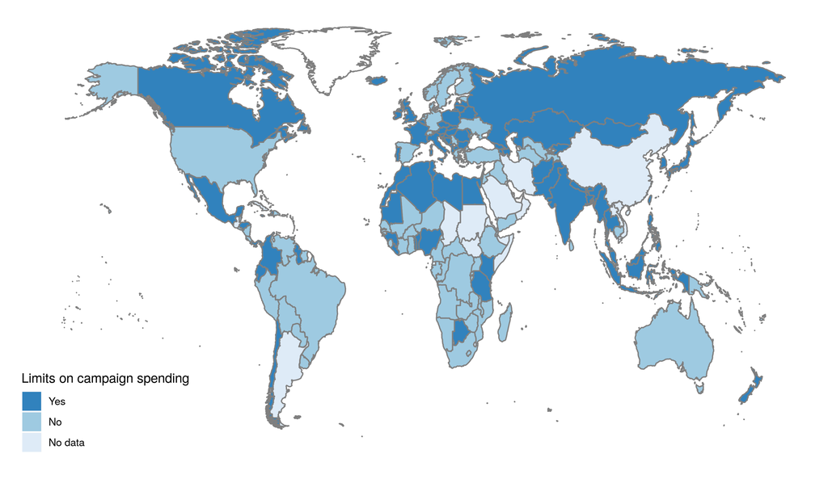

## Exercise Two

## Linear Regression Models

## `lm`

Linear regression models in R are implemented using the `lm` function.

```r
lm.fit <- lm(formula = y ~ x, data = sim.df)
```

The `formula` argument is the specification of the model, and the `data` argument is the data on which you would like the model to be estimated.

```r
lm.fit
```

```
##
## Call:
## lm(formula = y ~ x, data = sim.df)
##
## Coefficients:
## (Intercept)            x
##      0.4722       0.3269
```

## `lm`

We can specify multivariate models:

```r
lm.multi.fit <- lm(formula = y ~ x + z, data = sim.df)
```

Interaction models:

```r
lm.inter.fit <- lm(formula = y ~ x * z, data = sim.df)
```

Note that direct effects of `x` and `z` are also included, when interaction term is specified.

Fixed-effect models:

```r
lm.fe.fit <- lm(formula = y ~ x + g, data = sim.df)
```

And many more!

## `lm`

The output of the `lm` function is a long list of interesting output.

When we call the fitted object (e.g. `lm.fit`), we are presented only with the estimated coefficients.

For some more information of the estimated model, use `summary(fitted.model)`:

```r
lm.fit.summary <- summary(lm.fit)
lm.fit.summary
```

## `lm`

```
##
## Call:
## lm(formula = y ~ x, data = sim.df)
##
## Residuals:
##     Min      1Q  Median      3Q     Max
## -3.2203 -0.6610 -0.0249  0.6988  2.8859
##
## Coefficients:
##             Estimate Std. Error t value Pr(>|t|)
## (Intercept)  0.47217    0.03202  14.747   <2e-16 ***
## x            0.32686    0.03300   9.906   <2e-16 ***
## ---
## Signif. codes:  0 '***' 0.001 '**' 0.01 '*' 0.05 '.' 0.1 ' ' 1
##
## Residual standard error: 1.012 on 998 degrees of freedom
## Multiple R-squared:  0.08953,    Adjusted R-squared:  0.08862
## F-statistic: 98.14 on 1 and 998 DF,  p-value: < 2.2e-16
```

## `lm`

As with any other function, `summary(fitted.model)` returns an object. Here, it is a list. What is saved as the output of this function?

```r
names(lm.fit.summary)
```

```
##  [1] "call"          "terms"         "residuals"     "coefficients"
##  [5] "aliased"       "sigma"         "df"            "r.squared"
##  [9] "adj.r.squared" "fstatistic"    "cov.unscaled"
```

If we want to extract other information of interest from the fitted model object, we can use the `$` operator to do so:

```r
lm.fit.summary$r.squared
```

```
## [1] 0.08952873
```

## `lm`

Accessing elements from saved models can be very helpful in making comparisons across models.

Suppose we want to extract and compare \(R^2\) across different models.

```r
lm.r2 <- summary(lm.fit)$r.squared
lm.multi.r2 <- summary(lm.multi.fit)$r.squared
lm.inter.r2 <- summary(lm.inter.fit)$r.squared

r2.compare <- data.frame(
  model = c("bivariate", "multivariate", "interaction"),
  r.squared = c(lm.r2,
                lm.multi.r2,
                lm.inter.r2)
)
```

## `lm`

We can print the data frame containing values of \(R^2\):

```r
r2.compare
```

```
##          model  r.squared
## 1    bivariate 0.08952873
## 2 multivariate 0.08976396
## 3  interaction 0.10851819
```

Or we can plot them:

```r
ggplot(r2.compare, aes(x = model, y = r.squared))+
  geom_point(size = 4) +
  # Use `expression` to add 2 as a superscript to R
  ggtitle(expression(paste(R^{2}, " ", "Comparison"))) +
  theme_bw()
```

## `lm`

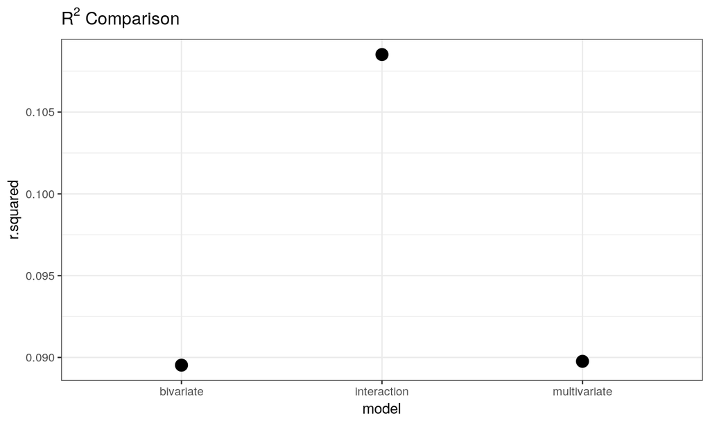

## `lm` diagnostics

There are a number of functions that are helpful in producing model diagnostics:

- `residuals(fitted.model)` extracts the residuals from a fitted model
- `coefficients(fitted.model)` extracts coefficients
- `fitted(fitted.model)` extracts fitted values
- `plot(fitted.model)` is a convenience function for producing a number of useful diagnostics plots

## `lm` residual plot

We can easily plot the residuals from a fitted model against an explanatory variable of interest.

Here we are going to exploit the modular nature of `ggplot`:

```r
# First, let's create common lower layers
first.layer <- ggplot() +
  # Draw horizontal line with y-intercept of 0
  geom_hline(yintercept = 0) +
  labs(y = "residuals") +
  theme_bw()
```

## `lm` residual plot

```r
# Now, we will create the first plot by adding a scatterplot of residuals for x
first.layer +
  geom_point(aes(x = sim.df$x,
                 y = residuals(lm.multi.fit)),
             # Change colour to grey
             colour = "grey") +
  labs(x = "x")
# Create another scatterplot for z
first.layer +
  geom_point(aes(x = sim.df$z,
                 y = residuals(lm.multi.fit)),
             colour = "grey") +
  labs(x = "z")
```

## `lm` residual plot

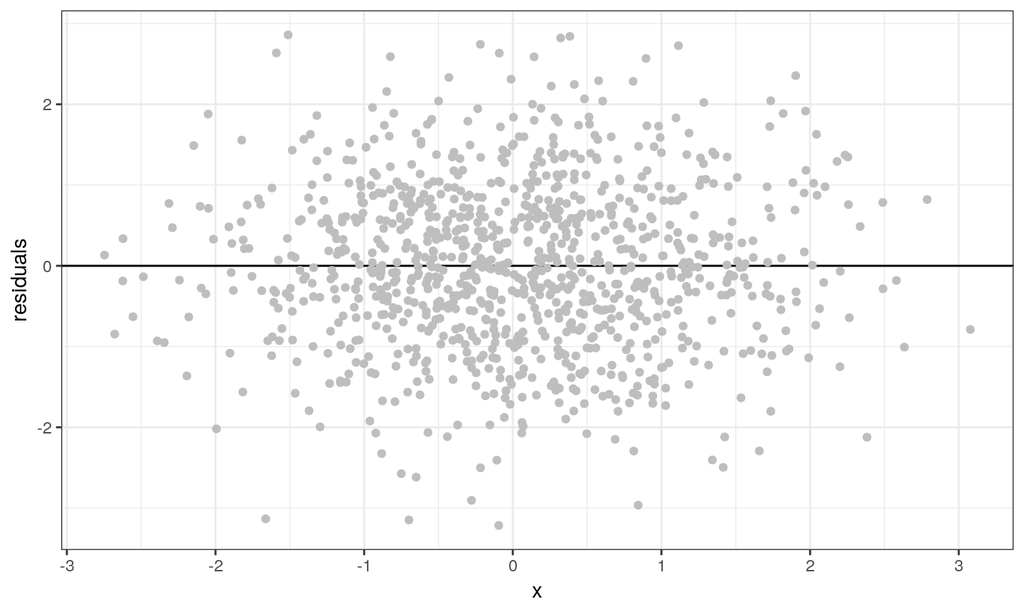

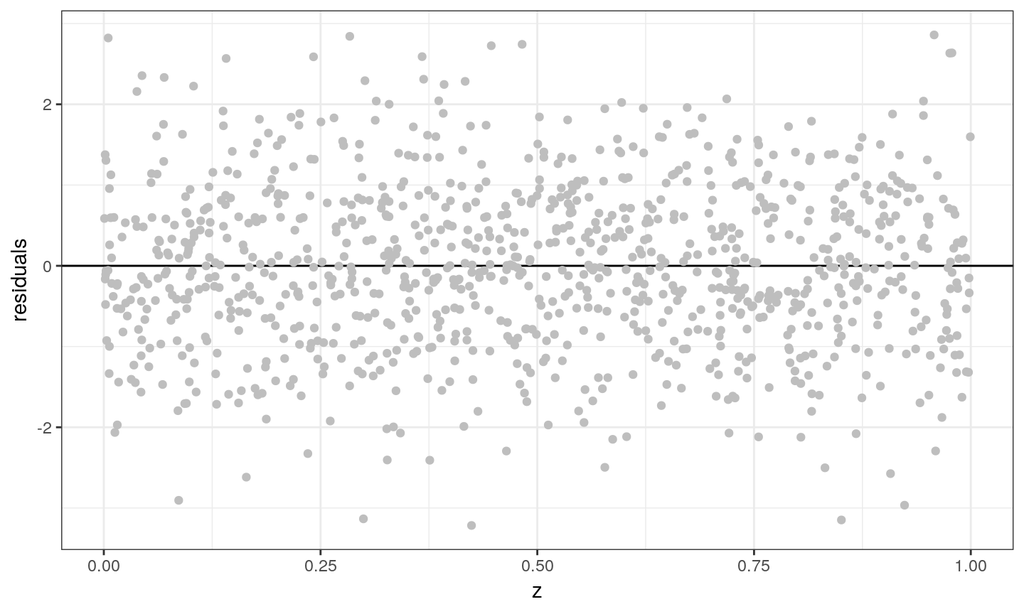

## `lm` residual plot

Alternatively, we can do that in base R:

```r
par(mfrow = c(1,2)) # Divide the plotting region into 1 row and 2 cols
plot(x = sim.df$x, y = residuals(lm.multi.fit),
     xlab = "x", ylab = "residuals",
     pch = 19, # Filled circles
     col = "grey", # Change colour
     cex = 0.5) # Make point size smaller
abline(h = 0) # Add a horizontal line with y-intercept of 0
plot(x = sim.df$z, y = residuals(lm.multi.fit),
     xlab = "z", ylab = "residuals",
     pch = 19, # Filled circles
     col = "grey", # Change colour
     cex = 0.5) # Make point size smaller
abline(h = 0) # Add a horizontal line with y-intercept of 0
```

## `lm` residual plot

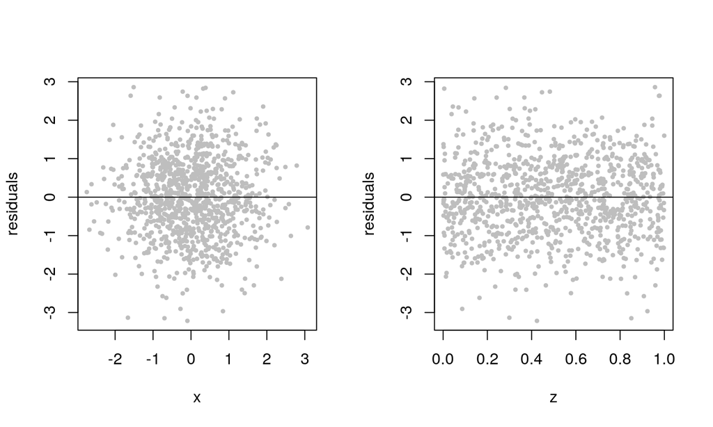

## Generalized Linear Models

## `glm`

To estimate a range of generalized linear models, the `glm` function is particularly helpful.

First, let us transform our outcome variable from a continuous measure to a binary measure:

```r
sim.df$y_bin <- as.numeric(sim.df$y > median(sim.df$y))
table(sim.df$y_bin)
```

```
##
##   0   1
## 500 500
```

## `glm`

Now we can estimate our model:

```r
logit.fit <- glm(formula = y_bin ~ x + z, data = df, family = "binomial")
```

Where:

- `formula` is the model specification
- `data` is our simulated data
- `family` is a description of the error distribution and link function to be used
  - `binomial`, `poisson`, `gaussian` etc…

## `glm`

```r
summary(logit.fit)
```

```
##
## Call:
## glm(formula = y_bin ~ x + z, family = "binomial", data = df)
##
## Deviance Residuals:
##      Min        1Q    Median        3Q       Max
## -1.80978  -1.12580  -0.01668   1.12790   1.72617
##
## Coefficients:
##             Estimate Std. Error z value Pr(>|z|)
## (Intercept) -0.09573    0.13140  -0.729    0.466
## x            0.55053    0.07159   7.690 1.47e-14 ***
## z            0.17674    0.22990   0.769    0.442
## ---
## Signif. codes:  0 '***' 0.001 '**' 0.01 '*' 0.05 '.' 0.1 ' ' 1
##
## (Dispersion parameter for binomial family taken to be 1)
##
##     Null deviance: 1386.3  on 999  degrees of freedom
## Residual deviance: 1320.9  on 997  degrees of freedom
## AIC: 1326.9
##
## Number of Fisher Scoring iterations: 4
```

## `glm`

Ok, but no-one actually thinks in terms of log-odds, so let's translate that into something more meaningful:

```r
logit.OR <- exp(cbind(OR = coef(logit.fit), confint(logit.fit)))
```

- `coef` extracts the coefficients
- `confint` extracts the confidence intervals
- `cbind` binds the vectors together as separate **c**olumns
- `exp` exponentiates the log-odds ratios

```r
round(logit.OR, digits = 4)
```

```
##                 OR  2.5 % 97.5 %
## (Intercept) 0.9087 0.7021 1.1755
## x           1.7342 1.5100 1.9997
## z           1.1933 0.7606 1.8740
```

## `glm`

Almost all of the convenience functions that we used for `lm` are also applicable to `glm` models:

```r
summary(logit.fit)
plot(logit.fit)
residuals(logit.fit)
coefficients(logit.fit)
fitted(logit.fit)
```

## Other models

There are a number of external packages that can make fitting other model types (relatively) straightforward:

- `lmer4` - Linear, generalised linear, and nonlinear hierarchical models
- `mcgv` - generalised additive models
- `survival` - survival analysis
- `glmnet` - lasso and elastic net regression models
- `randomForest` - random forest models from machine learning
- `rjags` and `rstan` - Bayesian models

To use a package that is not a part of the base R installation, use:

```r
install.packages("lmer4")
library("lmer4")
```

## `predict`

We can retrieve the fitted values from the model using `fitted()`, but we may be interested in calculating predicted values for arbitrary levels of our covariates.

```r
sim_data <- data.frame(x = c(0, 1))
y_hat <- predict(object = lm.fit, newdata = sim_data)
y_hat
```

```
##         1         2
## 0.4721722 0.7990340
```

Here, I am creating a `data.frame` with two observations of one variable (`x`).

I am then using the `predict` function, where

- `object = my_lm` tells R the model object for which prediction is desired
- `newdata = sim_data` tells R the values for which I would like predictions

## `predict`

We can use the same syntax to retrieve predictions for (marginally) more interesting models:

```r
sim.data <- data.frame(x = c(0, 0, 1, 1), z = c(0, 1, 0, 1))
sim.data
```

```
##   x z
## 1 0 0
## 2 0 1
## 3 1 0
## 4 1 1
```

```r
y.hat <- predict(lm.multi.fit, newdata = sim.data)
y.hat
```

```
##         1         2         3         4
## 0.4439052 0.5009562 0.7707532 0.8278042
```

## `predict`

This can be especially useful when trying to visualise interactive models:

```r
sim.data.z0 <- data.frame(x = seq(from = -2, to = 2, by = 0.01), z = 0)
sim.data.z1 <- data.frame(x = seq(from = -2, to = 2, by = 0.01), z = 1)
y.hat.z0 <- predict(lm.inter.fit, newdata = sim.data.z0)
y.hat.z1 <- predict(lm.inter.fit, newdata = sim.data.z1)
```

- `seq` generates a regular sequences `from` one value `to` another value `by` given increments
- I am creating two data frames for prediction, in both cases varying the value of `x`, but first setting `z` to 0, and then setting `z` to 1

## `predict`

```r
# Create a plot of the data
plot(sim.df$x, sim.df$y, cex = 0.5, pch = 19,
     col = "gray", bty = "n",
     xlab = "X", ylab = "Y",
     main = "Fitted values for sim_data")

# Add a prediction line for z = 0
lines(x = sim.data.z0$x, y = y.hat.z0, lwd = 2)

# Add a prediction line for z = 1
lines(x = sim.data.z1$x, y = y.hat.z1, lwd = 2, col = "red")

# Add a legend
legend("bottomright", legend = c("z = 0", "z = 1"), col = c("black", "red"), lty = 1)
```

## `predict`

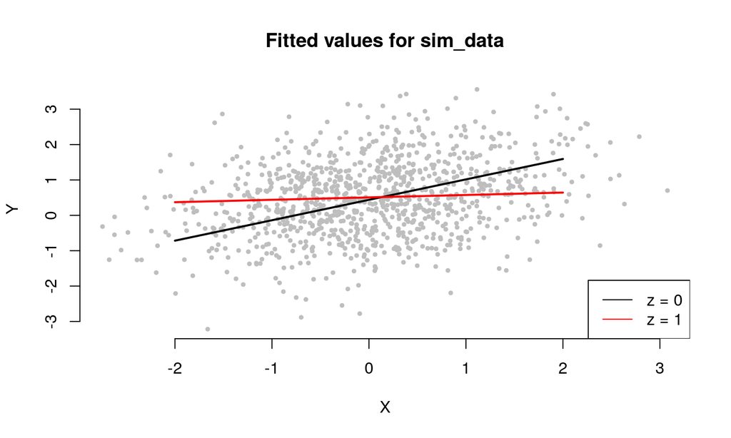

## Can we just use `margins`?

Yes! Thomas Leeper has created a package that implements the functionality of STATA `margins` command:

```r
library("margins")

margins::cplot(lm.inter.fit, x = "x", dx = "z", what = "effect")
```

`cplot` is equivalent to `marginsplot` in STATA.

The specification above tell `R` that we want to plot the marginal effect of `z` on `y` across the range of `x`.

## Can we just use `margins`?

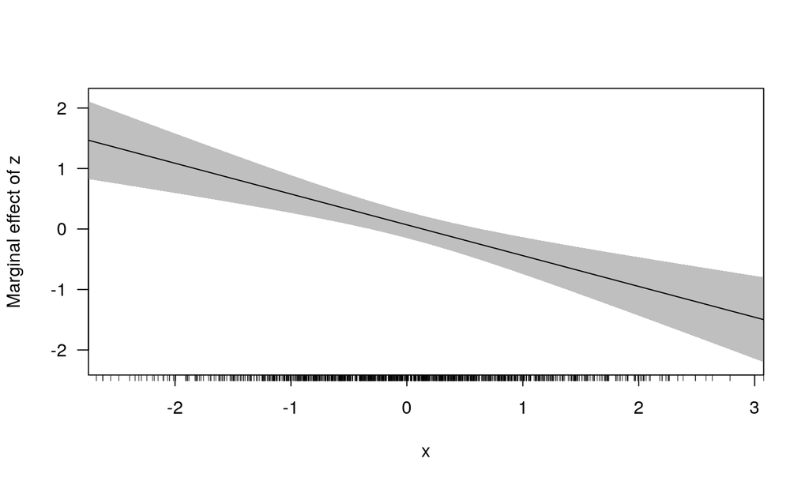

## Thank you!

## Any questions?

## Other helpful functions

```r
objects() & ls() # Which objects are currently loaded in my working environment?
rm() # Remove objects from my current environment
save() # Save R object(s) to disk
is.na() # Is this object a missing value? Or, which elements in this vector are missing?
rnorm() # Generate random numbers from a normal distribution
runif() # Generate random numbers from a uniform distribution
```

## Other helpful packages

- Check [tidyverse](https://www.tidyverse.org/) collection of packages:

```r
library("readr")
library("dplyr")
library("tidyr")
```

- If you need to get the most speed out of data.frame operations:

```r
library("data.table")
```

- For dealing with time series data:

```r
library("zoo")
library("lubridate")
```

## Further reading

- Crawley, M. J. (2012). *The R Book* 2nd Ed. Hoboken, NJ: Wiley-Blackwell.
- Dalgaard, P. (2008). *Introductory Statistics with R* 2nd Ed. Heidelberg: Springer.
- Fox, J. (2018). *An R Companion to Applied Regression* 3rd Ed. Thousand Oaks, CA: Sage Publications.
- Matloff, N. (2011). *The Art of R Programming*. San Francisco: No Starch Press.
- Wickham, H. (2014). *Advanced R Programming*. Chapman & Hall/CRC.
- Wickham, H., & Grolemund, G. (2017). *R for Data Science*. Sebastopol: O’Reilly Media.